# Quantitative Genetics

GxE: Biplots and Multiplicative models

Felipe Ferrão

University of Florida – September, 2022

**Objectives:**

- 20 minutes of hands-on
- metan R package

**Extra information**

- [HOS 6932 – Website](https://lfelipe-ferrao.github.io/class/survey/)
- About the [author](https://lfelipe-ferrao.github.io/)
- About the [UF/IFAS Plant Breeding](https://programs.ifas.ufl.edu/plant-breeding/)

# Introduction

In this class, we will introduce a classical idea of adaptability and stability. Most of the papers and studies carried out in multiple locations will present the GxE interaction in the form of biplots and discuss the selection of material that have a good performance over multiple sites/conditions (stable genotypes) or materials that are more adapted to a certain environment.

There are different models and software described in the literature that can provide such information. In the previews classes we discussed it in a mixed models context and presented interactions in the form of var-cov structures. In my opinion, this provide the best framework for modelling the GxE interaction and is powerful – in particular, because depending of the var-cov used it allows us borrowing informating across environments.

However, more parsimonious models also have their importance in the GxE literature. Herein we will present a group of methods based on multiplicative models that provide a simple representation of GxE. More importantly, all results have a simple interpretation and straightforward visualization – a fact that make this framework popular between breeders and biometricians.

# Theory

The use of biplots for representing the GxE interaction have been presented in different software. Herein, we will highlight two R packages:

- [metan](https://tiagoolivoto.github.io/metan/index.html)
- [statgenGxE](https://cran.r-project.org/web/packages/statgenGxE/vignettes/statgenGxE.html)

Both packages presented advantages and caveats. While `statgenGxE` allows to fit linear mixed models of varying complexity and different var-cov structures; `metan` present better representations. Herein, we will focus on the `metan` packag, in particular, because we would like to emphasize the importance on interpreting the results using graphical tools.

## AMMI models

The Additive Main Effects and Multiplicative Interaction (AMMI) model fits a linear model including additive main effects and multiplicative interaction effects. As indicated by its name, this class of models involves the product of a component due to genotypic term and a component due to the interaction.

The use of additive effects resemble the classical ANOVA analyses, in which the genotype is the main effect and GxE interaction effect is treated as a multiplicative effect using fixed models The multiplicative effects follow principal component analysis, and this is the way that the GxE interaction is accounted in the model.

We can write the model in the following way:

$$y_{ij} = \mu + G_i + E_j + \sum b_{ik}z_{ik} + e_{ij}$$

where the GxE is explained by a multiplicative term, that is formed by the product between genotype and environment interaction.

Main objective of AMMI analyses is to obtain estimates of the performance of a genotype in a particular environment. To this end, a desirable property of the is that the genotypic and environmental scores can be used to construct powerful graphical representations called **biplots**.The use of such tools can help breeders to explain the GxE interaction, since genotype and environment can be ploted in the same graphical.A central concept behind AMMI models is because the first few PCA axes tend to capture most of the interaction. Thus, environments are typically represented as axes intersecting at their origins.The origins represent the averages for the trait in the corresponding environments.

## GGE analyses

This is a classical two way ANOVA where the GxE term is represented as an interaction term in the linear model. Therefore, the model can be represented in the following way:

$$y_{ij} = \mu + G_i + E_j + GE_{ij}+ e_{ij}$$
What is interesting about this classical method is because the biplots can be constructed by the first two symmetrically scaled principal components (PC1 and PC2) derived from singular value decomposition of environment-centered data. Why this is valueable? Interpretation ! Using this approach we can identify stable and adaptable genotypes easily, compare environments, and take decisions usinf a parcimounus model.

# Hands on

We will use a real example in blueberry to illustrate the use of biplots for GxE analyses. The real data was described by [Sater et al., (2019)](https://www.sciencedirect.com/science/article/pii/S0304423821005756?dgcid=author), where we described the storage factors affecting sensory, physical and chemical attributes of six blueberry cultivars.

Some notes about this data set:

- Genotype: six blueberry cultivars (Keecrisp, Indigocrisp, Patricia, Endura, Emerald and Arcadia)
- Environment: three different storage factors (after 1 day, 8 days and 15 days in the cold condiction)
- Repetition: herein, we used two harvests during the season as our repetition
- Response variable: deflection (firmness of the berries)
- **Central question: what genotype is more sensible (in terms of firmness variation) to post-harvest conditions in blueberry?**

## AMMI analyses

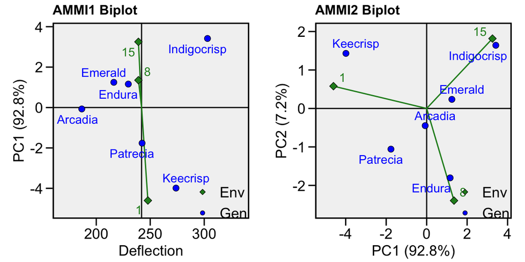

```r
library(metan)
library(dplyr)
library(openxlsx)
library(gridExtra)

# Download the data
setwd("~/Dropbox (UFL)/classes/QuantitativeGenetics_22/Class_Metan")
firmness = read.xlsx("./Summery Blueberry Instrmental Frimness 2015 2016.xlsx")

data = firmness %>%
  group_by(Cultivar,Harvest, Storage) %>%
  summarize_if(is.numeric, mean, na.rm=T) %>%
  select(Cultivar,Storage,Harvest,Deflection) %>%
  droplevels() %>%
  as.data.frame()

# Fitting models in metan
data$Cultivar = as.factor(data$Cultivar)
data$Storage = as.factor(data$Storage)
data$Harvest=as.factor(data$Harvest)
AMMI_model <- performs_ammi(data,
                            env = Storage,
                            gen = Cultivar,
                            rep=Harvest,
                            resp = Deflection,
                            verbose = F)
a1=plot_scores(AMMI_model)
a2=plot_scores(AMMI_model,type=2)
a3 = plot_scores(AMMI_model,type=4)
grid.arrange(a1,a2,ncol=2)
```

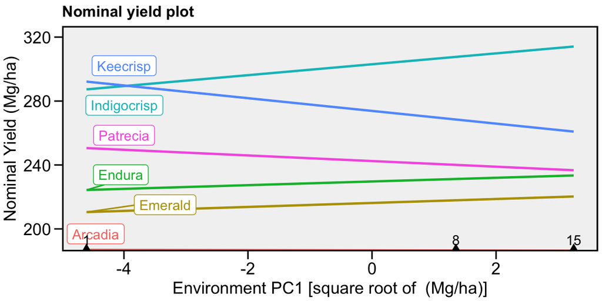

```r
a3
```

## GGE Analyses

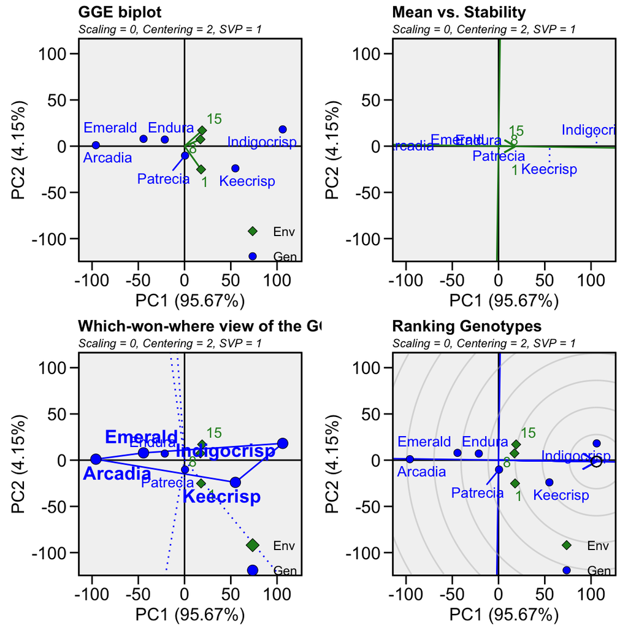

```r
library(metan)
library(gridExtra)
gge_model <- gge(data, Storage, Cultivar, Deflection,svp="genotype")
a= plot(gge_model)
b= plot(gge_model, type = 2)
c= plot(gge_model, type = 3)
d= plot(gge_model, type = 8)
grid.arrange(a,b,c,d,ncol=2)
```

**Interpretation**

Great advance on using the GGE method is the interpretation. We can create nice plots and see some important trend in the data.

- `type=1`: classical biplot
- `type 2`: Mean performance vs. stability. Herein, we draw an average environment coordinate (AEC) on the genotype-focused biplot (represented as a green line). The line that passes through the biplot origin and the AEC may be called the average. The projections of genotype markers onto this axis should, therefore, approximate the mean of the genotypes. Thus, `Indigocrisp` was clearly the best genotype, on average, while `Arcadia` showed the best stability, however a poor phenotypic performance.
- `type 3`: Which-won-where. A polygon is drawn joining the genotypes located farthest from the origin. The vertex genotypes are, therefore, among the most responsive genotypes in different environments. A genotype located at the origin would rank the same in all environments and is not at all responsive to the environments.
- `type 8`: Ranking genotypes. Compares all genotypes with the “ideal” genotype. The ideal genotype, represented by the small circle with an arrow pointing to it, is defined as having the highest phenotypic performance in all environments. Therefore, it combines stability and performance. In out example, `Indigocrisp` showed the best general performance.

# Conclusion

GxE interaction is a dynamic topic in plant breeding, where multiple methods and approaches have been proposed in the literature. The use of mixed models as presented along the course is maybe one of the most powerful and modern way to describe GxE and ranking genotypes. However, we have a group of more parsimonious models that have their (i) historical importance and (ii) straightforward implementation and visualization.

Herein, we focused on a gruop of regression models and focused on the interpretation of biplot graphics. My personal opinion: I like this kind of analyses. Not only because it is easy to be implemented, but also the interpretability. We can present this plots to any breeders, growers and/or statisticians and everyone will speak the the same language.

# References

- Yan, Weikai., and Manjit S. Kang. 2003. GGE biplot analysis : a graphical tool for breeders, geneticists, and agronomists. CRC Press.
- Yan, W., M. S. Kang, B. Ma, S. Woods, and P. L. Cornelius. 2007. “GGE Biplot vs. AMMI Analysis of Genotype-by-Environment Data.” Crop Science 47 (2): 641–53.
- Olivoto, T., and Lúcio, A.D. (2020). metan: an R package for multi-environment trial analysis. Methods Ecol Evol. 11:783-789 doi:10.1111/2041-210X.13384